# Data Visualization Analysis

**Global Font Settings:**

Set fonts for all text in a plot:

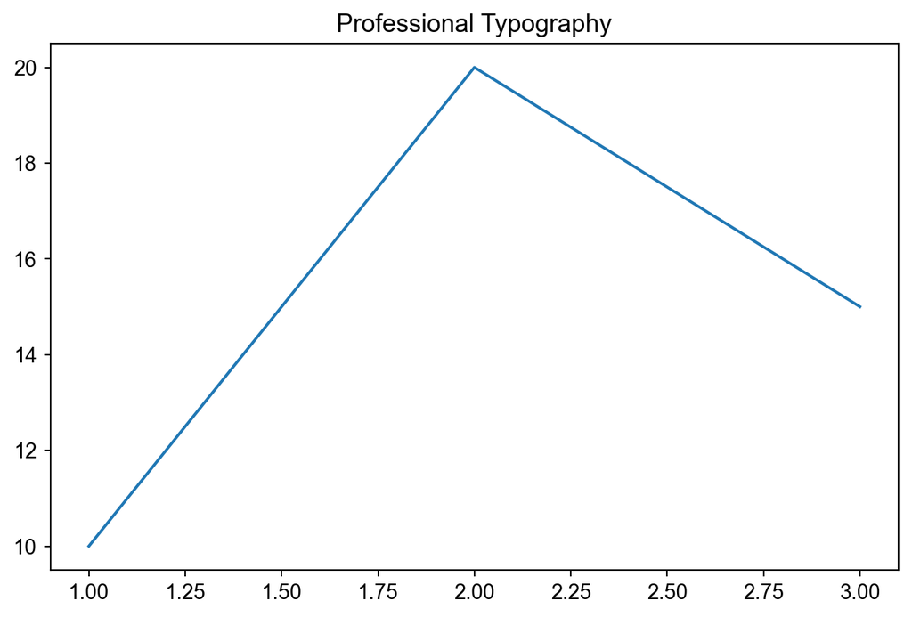

```python
import matplotlib.pyplot as plt

# Set font for all elements
plt.rcParams['font.family'] = 'sans-serif'
plt.rcParams['font.sans-serif'] = ['Arial', 'Helvetica', 'DejaVu Sans']
plt.rcParams['font.size'] = 11

fig, ax = plt.subplots(figsize=(8, 5))
ax.plot([1, 2, 3], [10, 20, 15])
ax.set_title('Professional Typography')
plt.show()
```

**Output:**

*[Line chart: “Professional Typography”]*

**Common Business Fonts:**

- **Arial**: Clean, professional, universally available
- **Helvetica**: Similar to Arial, elegant
- **Times New Roman**: Traditional, formal reports
- **Calibri**: Modern, Microsoft default
- **DejaVu Sans**: Good Matplotlib default with many characters

**Individual Text Customization:**

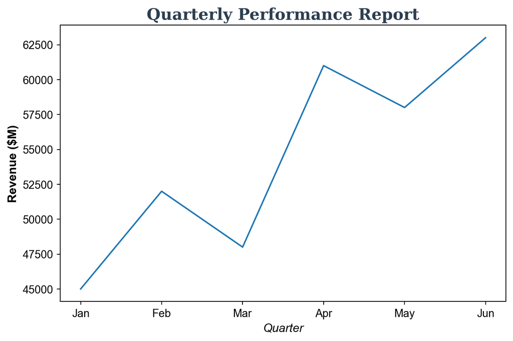

```python
fig, ax = plt.subplots(figsize=(8, 5))
ax.plot(months, sales)

# Title with custom font
ax.set_title('Quarterly Performance Report',
             fontsize=16,
             fontweight='bold',
             fontfamily='serif',
             color='#2C3E50')

# X-axis label
ax.set_xlabel('Quarter',
              fontsize=12,
              fontstyle='italic',
              fontweight='medium')

# Y-axis label
ax.set_ylabel('Revenue ($M)',
              fontsize=12,
              fontweight='bold')

plt.show()
```

**Output:**

*[Line chart: “Quarterly Performance Report”, x: Quarter, y: Revenue ($M)]*

**Font Property Options:**

- `fontsize`: Number (points) or string (‘small’, ‘medium’, ‘large’, ‘x-large’)
- `fontweight`: ‘normal’, ‘bold’, ‘heavy’, ‘light’, or numeric (100-900)
- `fontstyle`: ‘normal’, ‘italic’, ‘oblique’
- `fontfamily`: ‘serif’, ‘sans-serif’, ‘monospace’, ‘fantasy’, ‘cursive’
- `color`: Any valid color specification

**Text Hierarchy in Business Charts:**

Create visual hierarchy through sizing:

- **Title**: 14-16pt, bold
- **Axis labels**: 11-12pt, medium weight
- **Tick labels**: 10-11pt, normal weight
- **Annotations**: 9-10pt, normal weight
- **Legend**: 10-11pt, normal weight

**Axes Formatting and Number Display**

**The Challenge of Readability:**

Compare these Y-axis displays:

- `1500000` - Hard to read quickly
- `1,500,000` - Better, but takes space
- `1.5M` - Clear and compact
- `$1.5M` - Even more informative

**Formatting Axis Numbers:**

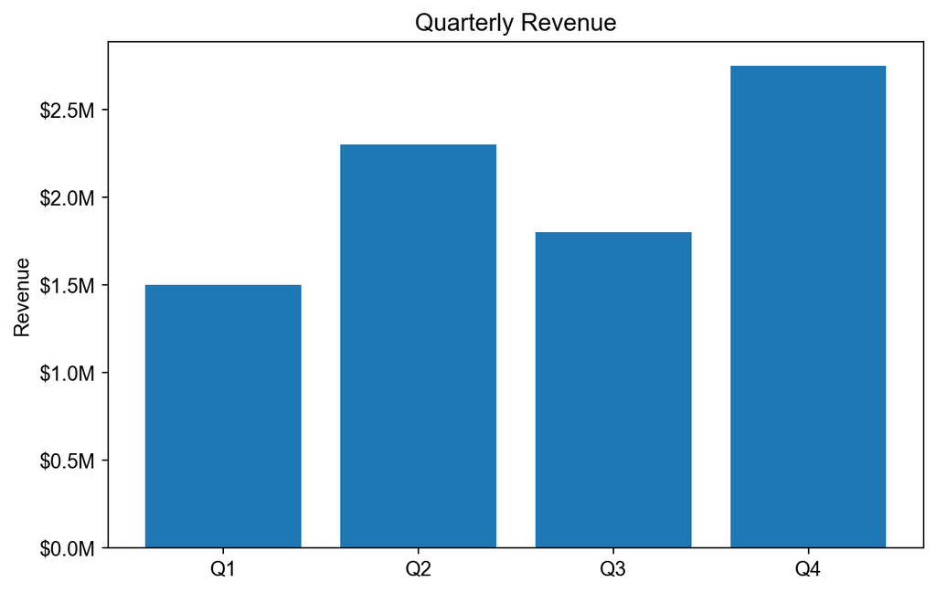

```python
import matplotlib.pyplot as plt
import matplotlib.ticker as ticker

revenue = [1500000, 2300000, 1800000, 2750000]
quarters = ['Q1', 'Q2', 'Q3', 'Q4']

fig, ax = plt.subplots(figsize=(8, 5))
ax.bar(quarters, revenue)

# Format Y-axis as millions with dollar sign
def millions_formatter(x, pos):
    return f'${x/1e6:.1f}M'

ax.yaxis.set_major_formatter(ticker.FuncFormatter(millions_formatter))

ax.set_title('Quarterly Revenue')
ax.set_ylabel('Revenue')

plt.show()
```

**Output:**

*[Bar chart: “Quarterly Revenue”, y: Revenue]*

**Common Number Formatters:**

```python
import matplotlib.ticker as ticker

# Add thousand separators
ax.yaxis.set_major_formatter(ticker.StrMethodFormatter('{x:,.0f}'))

# Percentage format
ax.yaxis.set_major_formatter(ticker.PercentFormatter(xmax=1))

# Currency format
ax.yaxis.set_major_formatter(ticker.StrMethodFormatter('${x:,.0f}'))

# Millions with 1 decimal
ax.yaxis.set_major_formatter(ticker.FuncFormatter(lambda x, p: f'{x/1e6:.1f}M'))

# Thousands shorthand
ax.yaxis.set_major_formatter(ticker.FuncFormatter(lambda x, p: f'{x/1000:.0f}K'))
```

**Controlling Tick Marks:**

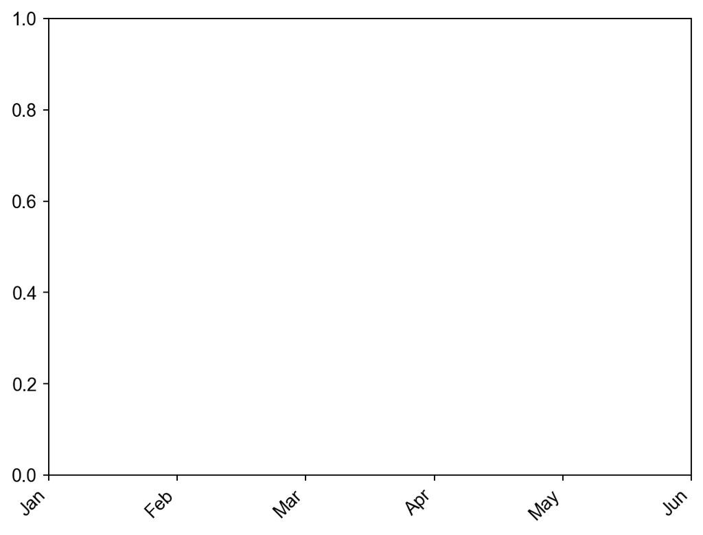

```python
import matplotlib.ticker as ticker

fig, ax = plt.subplots()
labels = ['Jan', 'Feb', 'Mar', 'Apr', 'May', 'Jun']

# Set specific tick locations
ax.set_xticks([0, 1, 2, 3, 4, 5])
ax.set_xticklabels(['Jan', 'Feb', 'Mar', 'Apr', 'May', 'Jun'])

# Rotate tick labels for readability
ax.set_xticklabels(labels, rotation=45, ha='right')

# Set number of ticks
ax.yaxis.set_major_locator(ticker.MaxNLocator(6))  # Approximately 6 ticks
plt.show()
```

**Bringing It All Together: Complete Customization**

**A Professional, Fully-Customized Chart:**

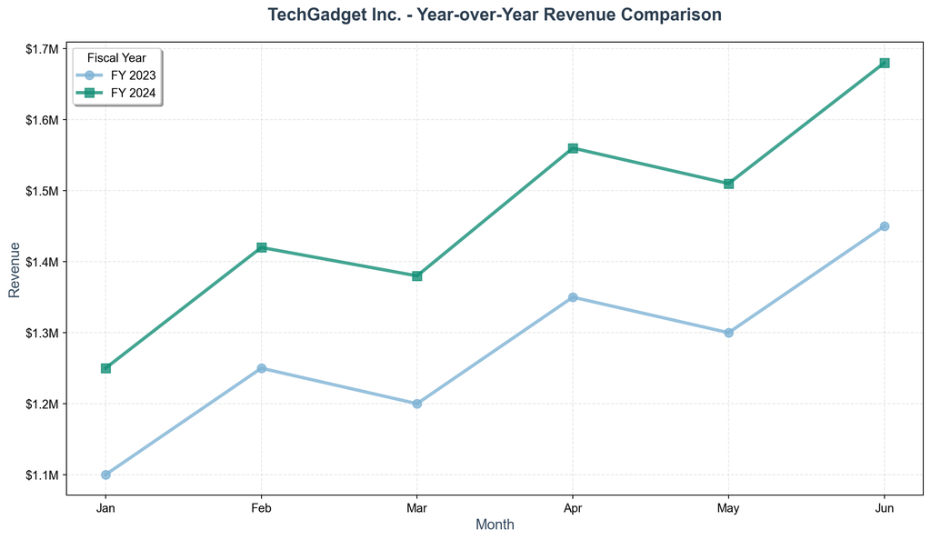

```python
import matplotlib.pyplot as plt
import matplotlib.ticker as ticker

# Data
months = ['Jan', 'Feb', 'Mar', 'Apr', 'May', 'Jun']
revenue_2023 = [1100000, 1250000, 1200000, 1350000, 1300000, 1450000]
revenue_2024 = [1250000, 1420000, 1380000, 1560000, 1510000, 1680000]

# Create figure with specific size
fig, ax = plt.subplots(figsize=(12, 7))

# Plot data with custom colors and styling
ax.plot(months, revenue_2023,
        color='#7FB3D5',      # Soft blue
        linewidth=3,
        marker='o',
        markersize=8,
        label='FY 2023',
        alpha=0.8)

ax.plot(months, revenue_2024,
        color='#148F77',      # Dark green
        linewidth=3,
        marker='s',
        markersize=8,
        label='FY 2024',
        alpha=0.8)

# Comprehensive labeling
ax.set_title('TechGadget Inc. - Year-over-Year Revenue Comparison',
             fontsize=16,
             fontweight='bold',
             pad=20,
             color='#2C3E50')

ax.set_xlabel('Month',
              fontsize=13,
              fontweight='medium',
              color='#34495E')

ax.set_ylabel('Revenue',
              fontsize=13,
              fontweight='medium',
              color='#34495E')

# Format Y-axis as millions
ax.yaxis.set_major_formatter(
    ticker.FuncFormatter(lambda x, p: f'${x/1e6:.1f}M')
)

# Customize legend
ax.legend(loc='upper left',
          fontsize=11,
          frameon=True,
          shadow=True,
          fancybox=True,
          title='Fiscal Year')

# Add grid for readability
ax.grid(True, alpha=0.3, linestyle='--', linewidth=0.8)

# Adjust layout
plt.tight_layout()

# Save and display
plt.savefig('M2L02_Revenue_Comparison.png', dpi=300, bbox_inches='tight')
plt.show()
```

**Output:**

*[Line chart: “TechGadget Inc. - Year-over-Year Revenue Comparison”, x: Month, y: Revenue]*

**Design Principles Applied:**

1. **Color**: Professional, accessible palette
2. **Contrast**: Clear difference between years
3. **Typography**: Hierarchical sizing
4. **Clarity**: Formatted axis, clear labels
5. **Professionalism**: Clean, polished appearance

### 2.2.3 Lab Session

**Lab 2: Professional Chart Customization**

**Objective:** Transform basic Matplotlib visualizations into polished, business-ready charts through comprehensive customization.

**Scenario:** You’re preparing for the annual shareholders’ meeting at “GlobalTech Solutions.” The CFO has reviewed your initial charts but requests significant improvements to make them boardroom-ready. Your task is to apply professional customization to create presentation-quality visualizations.

**Pre-Lab Setup:**

1. Create file: `M2L02_YourName_Customization.py`
2. Import libraries: matplotlib.pyplot and matplotlib.ticker
3. Create output folder: “Lab2_Outputs”

**Part A: Revenue Trend Enhancement (30 points)**

**Context:** The basic revenue chart lacks the polish needed for executive presentation. Transform it into a professional visualization.

**Data:**

```python
quarters = ['Q1 2024', 'Q2 2024', 'Q3 2024', 'Q4 2024']
revenue = [2400000, 2750000, 2650000, 3100000]
target = [2500000, 2600000, 2700000, 2800000]
```

**Tasks:**

1. **Create a dual-line comparison (12 points):**
   - Figure size: (12, 7)
   - Plot actual revenue with thick line (linewidth=3)
   - Plot target as dashed line (linestyle=‘–’)
   - Actual revenue: Dark blue color (#1F4788)
   - Target: Gray color (#7F8C8D)
   - Add circular markers (size 10) to actual revenue
   - Add square markers (size 10) to target
   - Include label for each line
2. **Apply professional formatting (12 points):**
   - Title: “GlobalTech Solutions - FY2024 Revenue vs. Target”
     - Font size: 16pt
     - Bold weight
     - Color: Dark gray (#2C3E50)
     - 20px padding above
   - X-axis label: “Quarter” (size 13, medium weight)
   - Y-axis label: “Revenue” (size 13, medium weight)
   - Format Y-axis numbers as: “$2.4M”, “$2.8M”, etc.
   - Add grid with 25% opacity, dashed lines
3. **Create an informative legend (6 points):**
   - Position: upper left
   - Font size: 12
   - Add frame with shadow
   - Rounded corners (fancybox=True)
   - Legend title: “Performance Metrics”

**Part B: Regional Sales Customization (30 points)**

**Context:** Create a professional bar chart comparing regional performance with clear visual hierarchy and formatting.

**Data:**

```python
regions = ['North America', 'Europe', 'Asia Pacific', 'Latin America', 'Middle East']
sales = [5800000, 4200000, 6500000, 2100000, 1800000]
```

**Tasks:**

1. **Create a styled bar chart (10 points):**
   - Figure size: (12, 6)
   - Use horizontal bars (ax.barh() instead of ax.bar())
   - Bar color: Professional green (#27AE60)
   - Add edge color: Dark green (#1E8449), width 1.5
   - Set alpha (transparency) to 0.8
2. **Format for executive presentation (15 points):**
   - Title: “Regional Sales Performance - 2024”
     - Font size: 15pt, bold
     - Color: Navy (#154360)
   - X-axis label: “Annual Sales Revenue”
   - Y-axis label: “Region”
   - Both labels: size 12pt, medium weight
   - Format X-axis as millions: “$5.8M”, “$4.2M”, etc.
   - Rotate X-axis labels 45 degrees if needed for clarity
3. **Add data labels on bars (5 points):**
   - Display exact sales value on each bar
   - Format as: “$5.8M”
   - Position at end of each bar
   - Font size: 11pt
   - Hint: Use a loop with ax.text()

**Part C: Multi-Series Comparison (25 points)**

**Context:** The product team needs a comparison of three product lines over time with distinct, accessible styling.

**Data:**

```python
months = ['Jan', 'Feb', 'Mar', 'Apr', 'May', 'Jun']
product_a = [85000, 92000, 88000, 95000, 102000, 98000]
product_b = [62000, 68000, 71000, 74000, 78000, 81000]
product_c = [45000, 43000, 48000, 52000, 55000, 58000]
```

**Tasks:**

1. **Create accessible visualization (12 points):**
   - Figure size: (12, 6)
   - Use colorblind-friendly palette:
     - Product A: Blue (#648FFF)
     - Product B: Orange (#FFB000)
     - Product C: Purple (#785EF0)
   - Line width: 2.5 for all
   - Different markers for each: ‘o’, ‘s’, ‘^’
   - Marker size: 9
   - Add labels for legend
2. **Professional formatting (8 points):**
   - Title: “Product Line Performance - H1 2024”
   - Clear axis labels with units
   - Format Y-axis with thousand separators: “85,000”
   - Add grid with subtle styling
   - Legend positioned to not obscure data
3. **Enhance readability (5 points):**
   - Add slight transparency (alpha=0.85) to lines
   - Ensure all text is size 11pt or larger
   - Use consistent font throughout
   - Add padding where needed for spacing

**Part D: Advanced Customization Challenge (15 points)**

**Context:** Create a visualization showing profit margins over time with conditional formatting (colors change based on performance).

**Data:**

```python
quarters = ['Q1', 'Q2', 'Q3', 'Q4']
profit_margins = [0.15, 0.18, 0.12, 0.21]  # 15%, 18%, 12%, 21%
```

**Tasks:**

1. **Create a conditional bar chart (10 points):**
   - If margin >= 0.15 (15%): Color green (#27AE60)
   - If margin < 0.15: Color red (#E74C3C)
   - Add edge color (black, width 2)
   - Figure size: (10, 6)
2. **Format as percentages (5 points):**
   - Y-axis should show: 15%, 18%, 12%, 21%
   - Add horizontal reference line at 15% (target)
     - Use ax.axhline()
     - Dashed line, gray color
     - Label it “Target: 15%”
   - Professional title and labels

**Bonus Challenge (+15 points):**

**Create a “Dashboard-Ready” Chart:**

Using any of the previous datasets or your own business scenario:

1. Apply company branding:
   - Choose a professional 2-3 color scheme
   - Use consistent typography
   - Add subtle design elements (e.g., accent lines)
2. Maximize information density:
   - Include multiple relevant metrics
   - Add annotations for key insights
   - Format all numbers appropriately
3. Make it presentation-ready:
   - High resolution (dpi=300)
   - Perfect sizing for PowerPoint (16:9 ratio)
   - No matplotlib artifacts (tight layout)

**Deliverables:**

1. Python file: `M2L02_YourName_Customization.py` with all parts
2. Five PNG files:
   - `M2L02_YourName_RevenueVsTarget.png`
   - `M2L02_YourName_RegionalSales.png`
   - `M2L02_YourName_ProductComparison.png`
   - `M2L02_YourName_ProfitMargins.png`
   - `M2L02_YourName_Bonus.png` (if attempted)

**Grading Rubric:**

- Part A: 30 points
- Part B: 30 points
- Part C: 25 points
- Part D: 15 points
- Bonus: +15 points

**Success Criteria:**

- All visualizations are professionally formatted
- Colors are appropriate and accessible
- All axes are clearly labeled with units
- Number formatting is business-appropriate
- Legends are clear and well-positioned
- Text hierarchy is established through sizing
- Charts are saved at high resolution
- Code is well-commented

**Professional Standards Checklist:**

For each chart, verify:

- Title clearly states what is shown
- Both axes labeled with units
- Numbers formatted appropriately (millions, thousands, percentages)
- Legend included when needed
- Color choices are intentional and accessible
- Font sizes are appropriate (title largest, labels medium, ticks smallest)
- Grid added for readability (subtle, not overwhelming)
- No default matplotlib styling remaining
- Saved with descriptive filename
- High resolution for professional use

**Tips for Success:**

- Review Section 2 examples before starting
- Test color combinations for readability
- View saved images to verify quality
- Get feedback on visual clarity
- Use comment blocks to organize code
- Reference matplotlib documentation for specific formatters

## 2.3 Section 3: Multiple Plots and Subplots

### 2.3.1 Objective

- Understand when and why to use multiple plots in a single figure
- Master the subplot architecture for creating multi-panel visualizations
- Create effective comparison layouts for business dashboards
- Control spacing, sizing, and alignment of multiple plots
- Share axes across subplots when appropriate
- Design cohesive multi-plot figures for reports and presentations

### 2.3.2 Main Contents with Examples

**The Business Case for Multiple Plots**

**Why Single Plots Aren’t Always Enough:**

Business analysis often requires viewing multiple perspectives simultaneously:

**Scenario 1: Regional Comparison** Instead of four separate charts for four regions, one figure with four subplots lets executives:

- Compare patterns across regions instantly
- Identify which regions are outperforming
- Spot regional trends vs. company-wide trends
- Present comprehensive analysis on one slide

**Scenario 2: Multi-Metric Dashboard** A product manager needs to see:

- Sales volume (line chart)
- Profit margins (bar chart)
- Customer satisfaction (line chart)
- Market share (area chart)

Four separate images become confusing. One dashboard figure tells the complete story.

**Scenario 3: Time Period Comparison** Comparing this year vs. last year:

- Option A: Overlay on same plot (can be cluttered)
- Option B: Side-by-side subplots (clearer comparison)
- Option C: Vertical stack (emphasizes temporal progression)

**Benefits of Subplots:**

1. **Space Efficiency**: Multiple insights on one page
2. **Easier Comparison**: Eye doesn’t need to switch between pages
3. **Professional Presentation**: Cohesive, dashboard-like appearance
4. **Storytelling**: Guide viewers through related analyses
5. **Print-Friendly**: One figure to include in reports

**When NOT to Use Subplots:**

- Data relationships aren’t related (create separate figures)
- Too many subplots (>6 becomes crowded)
- Plots need different scales that confuse comparison
- Each plot tells a completely different story

**Understanding Subplot Architecture**

**The Conceptual Model:**

Think of subplots as a grid:

- **Rows**: Vertical divisions
- **Columns**: Horizontal divisions
- **Position**: Each subplot occupies a cell (or multiple cells)

```
2 rows, 2 columns:
┌─────────┬─────────┐
│ (0,0)   │ (0,1)   │  Row 0
├─────────┼─────────┤
│ (1,0)   │ (1,1)   │  Row 1
└─────────┴─────────┘
 Column 0  Column 1
```

**Basic Subplot Creation:**

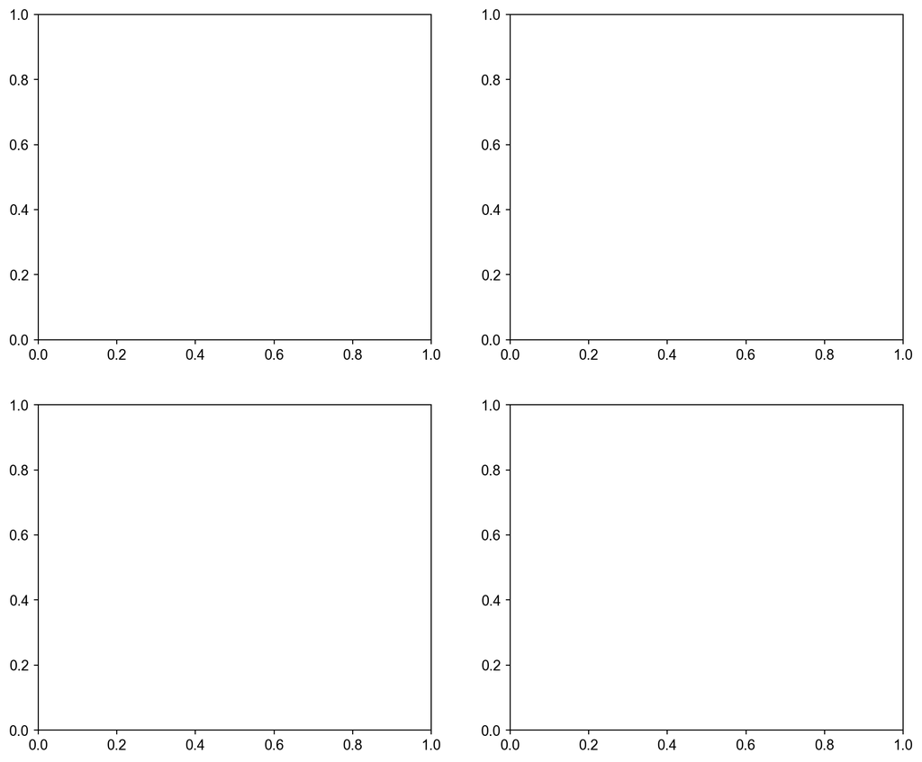

```python
import matplotlib.pyplot as plt

# Create a figure with 2x2 grid of subplots
fig, axes = plt.subplots(2, 2, figsize=(12, 10))

# Access individual subplots
axes[0, 0]  # Top-left
axes[0, 1]  # Top-right
axes[1, 0]  # Bottom-left
axes[1, 1]  # Bottom-right
```

**Output:**

*[Chart: 2Ã—2 subplot grid]*

**Important Notes:**

- `axes` is a 2D array if you have rows and columns
- `axes` is a 1D array if you have only rows OR columns
- Use `axes.flatten()` to convert 2D to 1D for easier iteration

**Creating Different Layout Configurations:**

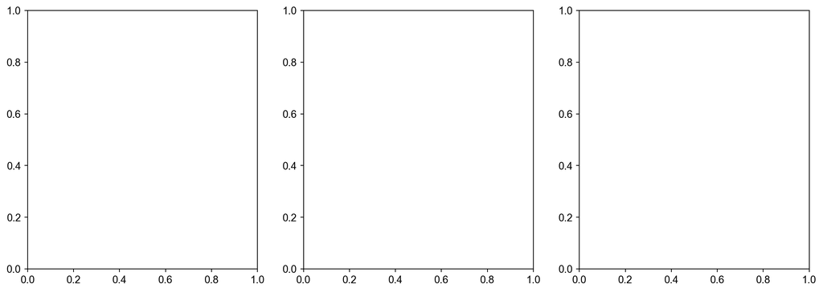

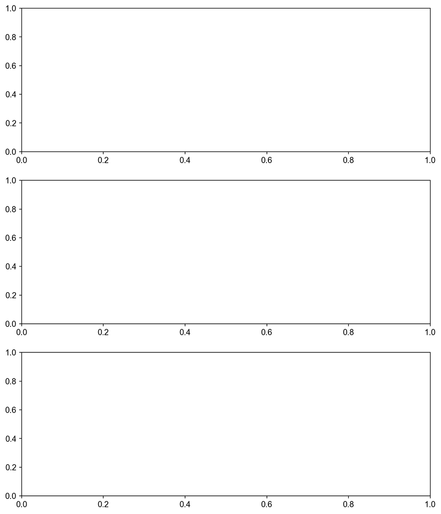

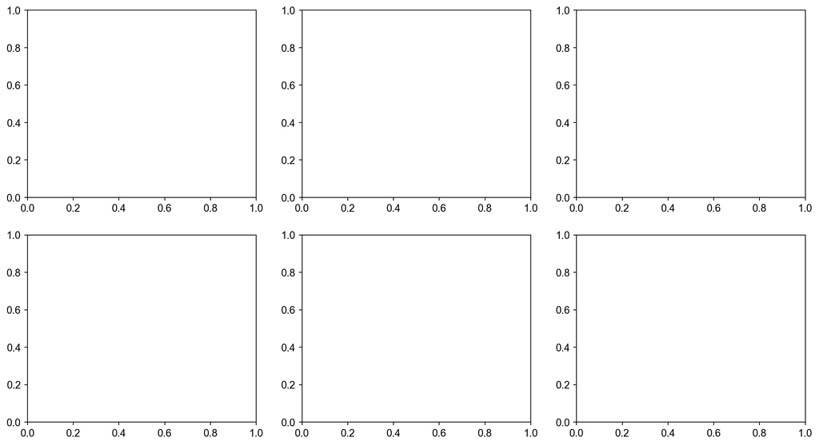

```python
# One row, three columns (horizontal dashboard)
fig, axes = plt.subplots(1, 3, figsize=(15, 5))

# Three rows, one column (vertical report)
fig, axes = plt.subplots(3, 1, figsize=(10, 12))

# 2x3 grid (six panels)
fig, axes = plt.subplots(2, 3, figsize=(15, 8))
```

**Output:**

*[Chart: 1Ã—3 subplot grid]*

**Creating a Simple Multi-Plot Dashboard**

**Example: Quarterly Business Dashboard**

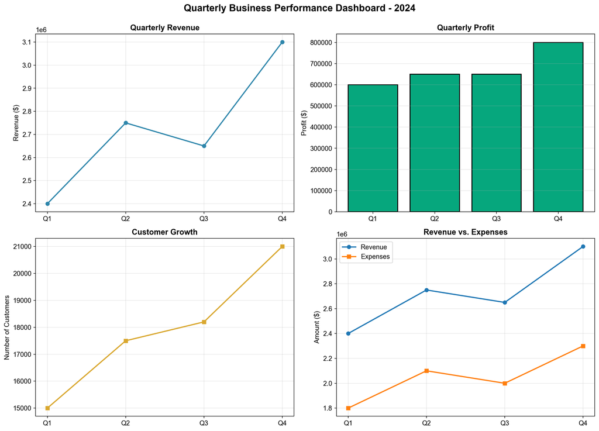

```python
import matplotlib.pyplot as plt
import numpy as np

# Sample data
quarters = ['Q1', 'Q2', 'Q3', 'Q4']
revenue = [2400000, 2750000, 2650000, 3100000]
expenses = [1800000, 2100000, 2000000, 2300000]
profit = [r - e for r, e in zip(revenue, expenses)]
customers = [15000, 17500, 18200, 21000]

# Create 2x2 dashboard
fig, axes = plt.subplots(2, 2, figsize=(14, 10))

# Top-left: Revenue trend
axes[0, 0].plot(quarters, revenue, marker='o', linewidth=2, color='#2E86AB')
axes[0, 0].set_title('Quarterly Revenue', fontsize=13, fontweight='bold')
axes[0, 0].set_ylabel('Revenue ($)')
axes[0, 0].grid(True, alpha=0.3)

# Top-right: Profit margins
axes[0, 1].bar(quarters, profit, color='#06A77D', edgecolor='black', linewidth=1.5)
axes[0, 1].set_title('Quarterly Profit', fontsize=13, fontweight='bold')
axes[0, 1].set_ylabel('Profit ($)')
axes[0, 1].grid(True, alpha=0.3, axis='y')

# Bottom-left: Customer growth
axes[1, 0].plot(quarters, customers, marker='s', linewidth=2, color='#D9A72E')
axes[1, 0].set_title('Customer Growth', fontsize=13, fontweight='bold')
axes[1, 0].set_ylabel('Number of Customers')
axes[1, 0].grid(True, alpha=0.3)

# Bottom-right: Revenue vs. Expenses comparison
axes[1, 1].plot(quarters, revenue, marker='o', label='Revenue', linewidth=2)
axes[1, 1].plot(quarters, expenses, marker='s', label='Expenses', linewidth=2)
axes[1, 1].set_title('Revenue vs. Expenses', fontsize=13, fontweight='bold')
axes[1, 1].set_ylabel('Amount ($)')
axes[1, 1].legend()
axes[1, 1].grid(True, alpha=0.3)

# Overall title for dashboard
fig.suptitle('Quarterly Business Performance Dashboard - 2024',
             fontsize=16, fontweight='bold', y=0.995)

plt.tight_layout()
plt.savefig('M2L03_Business_Dashboard.png', dpi=300, bbox_inches='tight')
plt.show()
```

**Output:**

*[Chart: “Quarterly Revenue”, 2Ã—2 subplot grid, y: Revenue ($)]*

**Key Techniques Applied:**

1. Each subplot accessed by index: `axes[row, col]`
2. Each subplot formatted independently
3. `fig.suptitle()` adds overall title
4. `tight_layout()` prevents overlapping elements

**Controlling Subplot Spacing and Layout**

**The Problem of Overlap:**

Default spacing often causes:

- Titles overlapping adjacent plots
- Axis labels getting cut off
- Cramped appearance
- Unprofessional look

**Solution 1: tight_layout() - Automatic Adjustment**

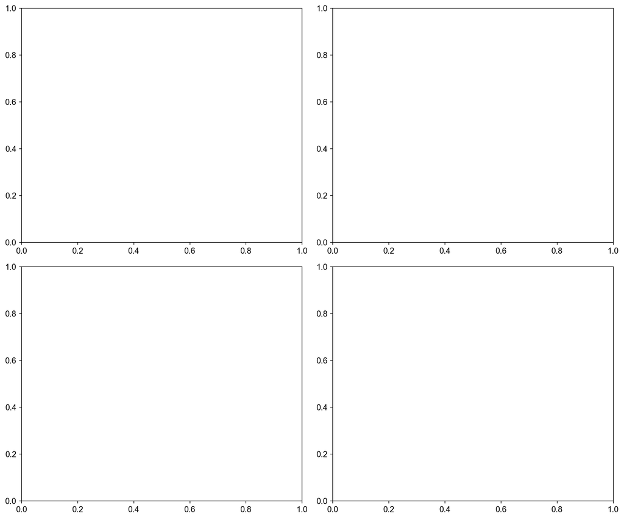

```python
fig, axes = plt.subplots(2, 2, figsize=(12, 10))

# ... create your plots ...

# Automatically adjust spacing
plt.tight_layout()
```

**Output:**

*[Chart: 2Ã—2 subplot grid]*

What `tight_layout()` does:

- Calculates optimal spacing
- Prevents overlapping elements
- Adjusts subplot sizes
- Usually “just works”

**Solution 2: subplots_adjust() - Manual Control**

For finer control:

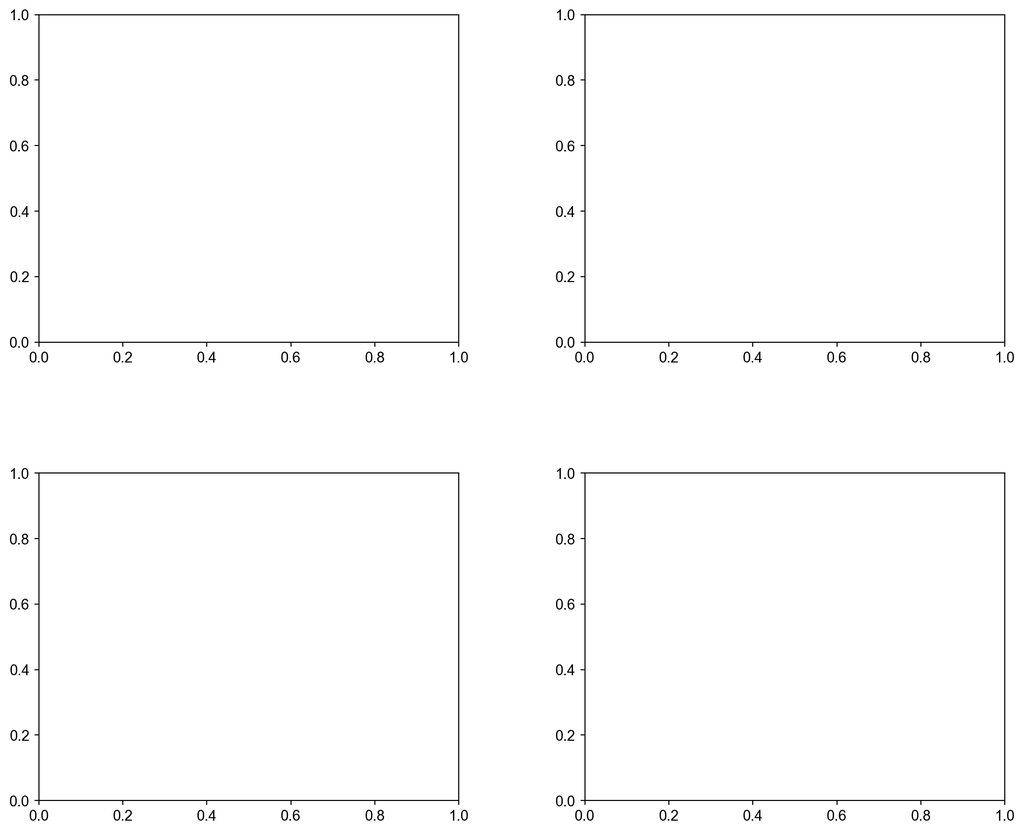

```python
fig, axes = plt.subplots(2, 2, figsize=(12, 10))

# ... create your plots ...

# Manual spacing adjustment
plt.subplots_adjust(
    left=0.1,      # Left margin
    right=0.95,    # Right margin
    top=0.93,      # Top margin
    bottom=0.1,    # Bottom margin
    wspace=0.3,    # Width space between subplots
    hspace=0.4     # Height space between subplots
)
```

**Output:**

*[Chart: 2Ã—2 subplot grid]*

**When to use manual adjustment:**

- `tight_layout()` doesn’t work well
- Need consistent spacing across multiple figures
- Creating very specific layouts
- Preparing for publication with strict requirements

**Sharing Axes Across Subplots**

**The Comparison Challenge:**

When comparing across subplots, inconsistent axis scales mislead viewers:

**Without shared axes:**

- Plot A: Y-axis 0-1000
- Plot B: Y-axis 0-5000
- Visual impression: Similar heights, but values are 5x different!

**Solution: Share X and/or Y Axes**

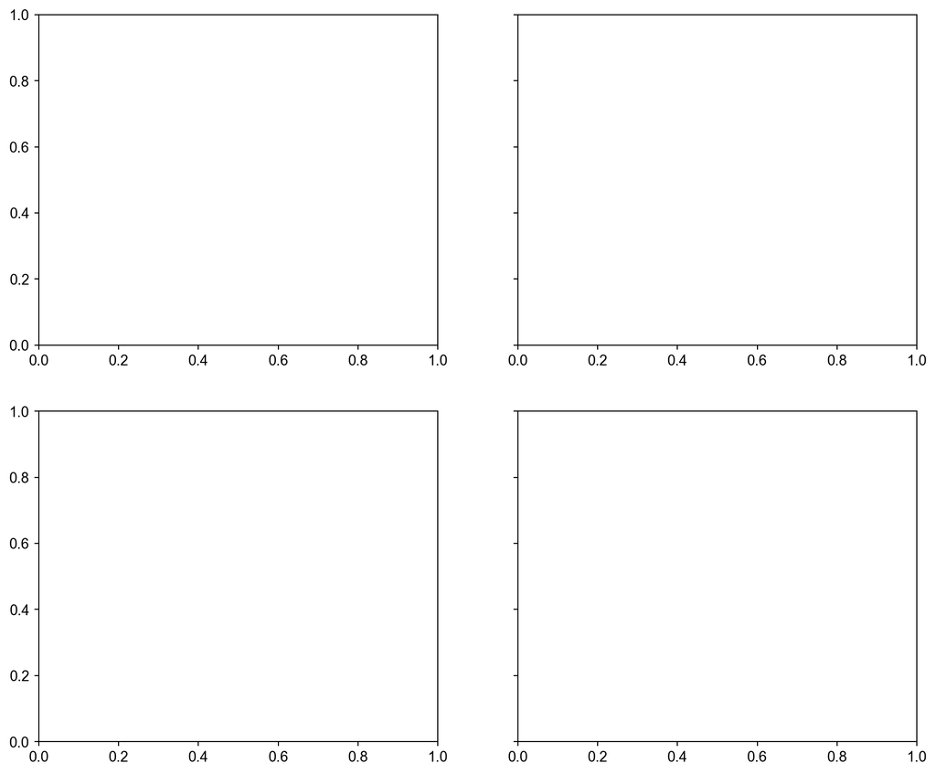

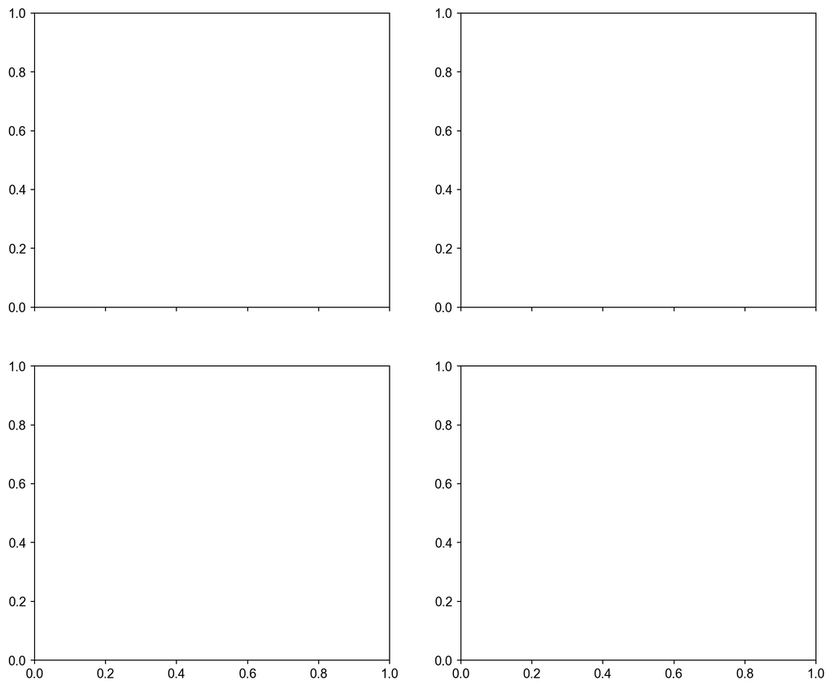

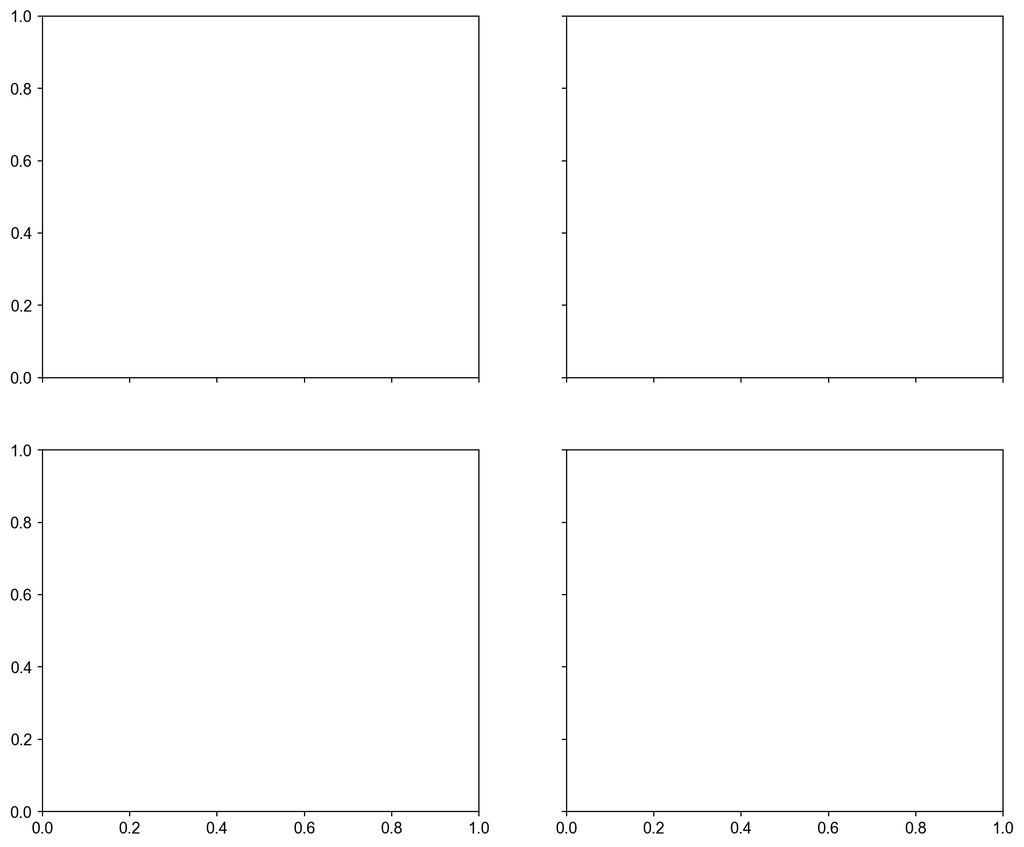

```python
# Share Y-axis across all subplots (common scale)
fig, axes = plt.subplots(2, 2, figsize=(12, 10), sharey=True)

# Share X-axis across all subplots
fig, axes = plt.subplots(2, 2, figsize=(12, 10), sharex=True)

# Share both
fig, axes = plt.subplots(2, 2, figsize=(12, 10), sharex=True, sharey=True)
```

**Output:**

*[Chart: 2Ã—2 subplot grid]*

**Practical Example: Regional Sales Comparison**

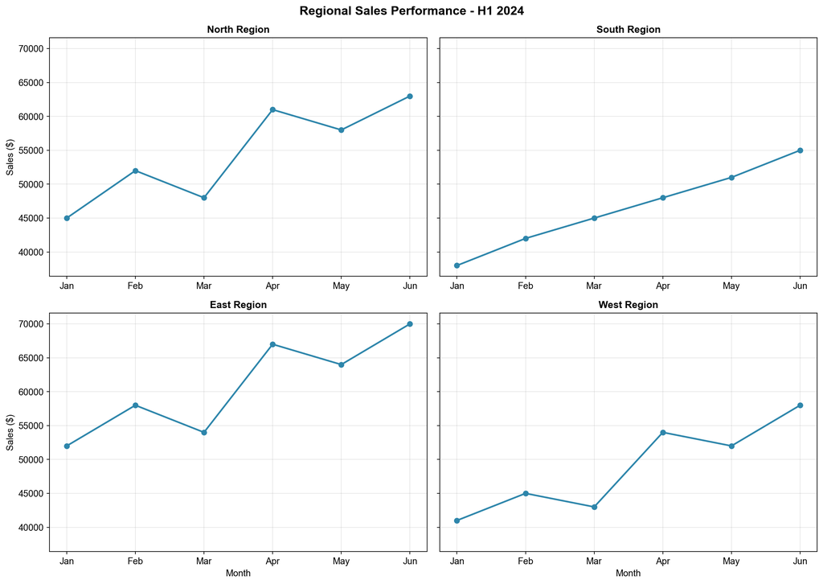

```python
import matplotlib.pyplot as plt

# Data for four regions
months = ['Jan', 'Feb', 'Mar', 'Apr', 'May', 'Jun']
north = [45000, 52000, 48000, 61000, 58000, 63000]
south = [38000, 42000, 45000, 48000, 51000, 55000]
east = [52000, 58000, 54000, 67000, 64000, 70000]
west = [41000, 45000, 43000, 54000, 52000, 58000]

# Create 2x2 grid with shared Y-axis for fair comparison
fig, axes = plt.subplots(2, 2, figsize=(14, 10), sharey=True)

# North region
axes[0, 0].plot(months, north, marker='o', color='#2E86AB', linewidth=2)
axes[0, 0].set_title('North Region', fontsize=12, fontweight='bold')
axes[0, 0].grid(True, alpha=0.3)

# South region
axes[0, 1].plot(months, south, marker='o', color='#2E86AB', linewidth=2)
axes[0, 1].set_title('South Region', fontsize=12, fontweight='bold')
axes[0, 1].grid(True, alpha=0.3)

# East region
axes[1, 0].plot(months, east, marker='o', color='#2E86AB', linewidth=2)
axes[1, 0].set_title('East Region', fontsize=12, fontweight='bold')
axes[1, 0].set_xlabel('Month')
axes[1, 0].grid(True, alpha=0.3)

# West region
axes[1, 1].plot(months, west, marker='o', color='#2E86AB', linewidth=2)
axes[1, 1].set_title('West Region', fontsize=12, fontweight='bold')
axes[1, 1].set_xlabel('Month')
axes[1, 1].grid(True, alpha=0.3)

# Common Y-label (only on left plots due to sharey)
axes[0, 0].set_ylabel('Sales ($)', fontsize=11)
axes[1, 0].set_ylabel('Sales ($)', fontsize=11)

fig.suptitle('Regional Sales Performance - H1 2024', fontsize=15, fontweight='bold')

plt.tight_layout()
plt.show()
```

**Output:**

**Benefits of Sharing Axes:**

- Honest visual comparison (same scale)
- Less cluttered (fewer axis labels)
- Professional appearance
- Easier to spot performance differences

**Mixing Different Plot Types**

**Telling Different Stories in One Figure:**

Complex business analyses require different visualization types for different metrics.

**Example: Comprehensive Product Analysis**

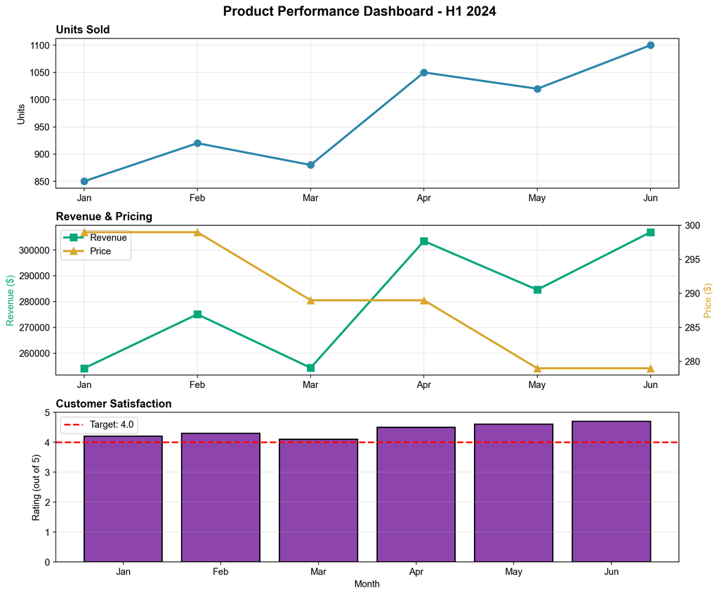

```python
import matplotlib.pyplot as plt
import numpy as np

# Data
months = ['Jan', 'Feb', 'Mar', 'Apr', 'May', 'Jun']
units_sold = [850, 920, 880, 1050, 1020, 1100]
price = [299, 299, 289, 289, 279, 279]
revenue = [u * p for u, p in zip(units_sold, price)]
satisfaction = [4.2, 4.3, 4.1, 4.5, 4.6, 4.7]

# Create 3-panel vertical layout
fig, axes = plt.subplots(3, 1, figsize=(12, 10))

# Panel 1: Sales Volume (Line Chart)
axes[0].plot(months, units_sold, marker='o', linewidth=2.5,
             color='#2E86AB', markersize=8)
axes[0].set_title('Units Sold', fontsize=13, fontweight='bold', loc='left')
axes[0].set_ylabel('Units', fontsize=11)
axes[0].grid(True, alpha=0.3)

# Panel 2: Revenue and Price (Dual Line Chart)
ax2_twin = axes[1].twinx()  # Create secondary Y-axis
axes[1].plot(months, revenue, marker='s', linewidth=2.5,
             color='#06A77D', label='Revenue', markersize=8)
ax2_twin.plot(months, price, marker='^', linewidth=2.5,
              color='#D9A72E', label='Price', markersize=8)
axes[1].set_title('Revenue & Pricing', fontsize=13, fontweight='bold', loc='left')
axes[1].set_ylabel('Revenue ($)', fontsize=11, color='#06A77D')
ax2_twin.set_ylabel('Price ($)', fontsize=11, color='#D9A72E')
axes[1].grid(True, alpha=0.3)

# Combine legends
lines1, labels1 = axes[1].get_legend_handles_labels()
lines2, labels2 = ax2_twin.get_legend_handles_labels()
axes[1].legend(lines1 + lines2, labels1 + labels2, loc='upper left')

# Panel 3: Customer Satisfaction (Bar Chart)
axes[2].bar(months, satisfaction, color='#8E44AD', edgecolor='black', linewidth=1.5)
axes[2].set_title('Customer Satisfaction', fontsize=13, fontweight='bold', loc='left')
axes[2].set_xlabel('Month', fontsize=11)
axes[2].set_ylabel('Rating (out of 5)', fontsize=11)
axes[2].axhline(y=4.0, color='red', linestyle='--', linewidth=2, label='Target: 4.0')
axes[2].legend()
axes[2].grid(True, alpha=0.3, axis='y')
axes[2].set_ylim([0, 5])

# Overall title
fig.suptitle('Product Performance Dashboard - H1 2024',
             fontsize=16, fontweight='bold')

plt.tight_layout()
plt.show()
```

**Output:**